# Day 1 - Fitting Models of Response Time

TVZ

Here are some of the libraries that we’re going to need.

```r
# install.packages("rtdists")"
# install.packages("remotes")
library("rtdists")
library("extraDistr")
library("muhaz")
library("moments")
library('gamlss')
library('PWEXP')
```

Load the Wagenmakers dataset

```r
load("wagenmakers.Rdata")
```

Here are some functions for the kernel estimators of the pdf, cdf and hazard functions.

```r
# Silverman's plugin bandwidth for kernel estimators
silverman <- function(data) {
    A <- min(c(sd(data),IQR(data)/1.34))
    N <- length(data)
    return((4/3)^.2 * A * N^(-.2))
    }

# A Gaussian kernel density estimate
# Compare with R's density(data)
kernel.density <- function(data,points=data) {
    N <- length(data)
    points <- unique(sort(points))
    # Silverman's bandwidth is the standard deviation of the normal kernel
    h <- silverman(data)
    f <- vector()
    for (i in 1:length(points)) {
        # Every observation is weighted by its distance from the point
        z <- (points[i]-data)/h
        kernel <- dnorm(z)
        # ... and then averaged
        f[i] <- mean(kernel)/h
    }
    return(cbind(points=points,f=f))
    }

# Gaussian kernel estimate of the CDF
cdf <- function(data,points=data) {
    N <- length(data)
    points <- unique(sort(points))
    h <- silverman(data)
    ps <- vector()
    for (i in 1:length(points)) {
       z <- (points[i]-data)/h
       # Average the points weighted by the integrated kernel
       kernel <- pnorm(z)
       ps[i] <- mean(kernel)
       }
    return(cbind(points=points,ps=ps))
}

# Gaussian kernel estimate of the hazard function
hazard <- function(data,points=data) {
    N <- length(data)
    points <- unique(sort(points))
    # Compute the appropriate ratio of the kernel estimates of the
    # density and survivor functions
    f <- kernel.density(data,points)
    F <- cdf(data,points)
    h <- f[,2]/(1 - F[,2])
    return(cbind(points=points,h=h))
    }
```

# Analysis of Response Times

What is involved in analyzing response times (RTs)? Let’s first break down the kind of experiment that produces RT data.

The experiment will ask some number $N$ of participants to make $n$ responses to some kind of task (usually a choice task). There may be $J$ conditions in the task (e.g., easy vs. hard), and these conditions may be either repeated within participants or be between participants.

For each participant by condition “cell” in the design, we can compute a mean RT for each participant, then compute a condition mean by averaging the participant means. (Note that this strategy opens the door to Simpson’s Paradox: a pattern may hold in the condition means that does not hold for the participant means.)

Analyzing RT data by way of means, means that are then subjected to t-tests or ANOVA, obscures much information about the data, information that can help us uncover the kinds of processes that generated the response. For this reason we usually analyze RT data at a *distribution* level.

As we go through these kinds of analyses, keep in mind the simplifying assumptions that you have to make. Some of these include

1. Individual participants engage exactly the same cognitive process to perform the task. There are no variations in strategy across participants.
2. Individual participants also use exactly the same process parameters (bias, information accumulation rate, etc.).
3. The RTs collected over trials are independent. A slow RT on trial 6 does not influence the RT on trial 7.
4. The RTs collected over trials are identically distributed. The distribution that describes how RTs are distributed at the end of the experiment is the same as the distribution that describes the RTs at the beginning.
5. Related to 4., there is no variation in the process used to perform the task during an individual’s participation.
6. Related to 4., process parameters are constant and do not vary over time, they only vary because of changing task demands.

Sometimes we make these assumptions for the sake of simplicity. Rarely do we because we believe them to be true.

# Probability

RTs are random variables. Random variables are described by their distributions. R uses 4 functions (a “quad”) to define a distribution. The name of the distribution has a “root” (e.g., “norm” for the normal distribution) and then

1. dnorm: the normal density function
2. pnorm: the cumulative normal distribution function
3. qnorm: the normal quantile function (the inverse of pnorm)
4. rnorm: the normal random number generator

The rtdists package contains the quads for the Ratcliff drift diffusion model (ddm) and several versions of the Brown & Heathcote linear ballistic accumulator (lba).

```r
# Simulate observations from a gamma distribution and compute their mean and variance
bignum <- 10000 # Sample size is really really big
k <- 4
alpha <- .5
X <- rgamma(bignum,shape=k,scale=alpha)
```

# Functions that Define a Distribution

Most random variables have a closed-form distribution function $F(x)$, which gives the probability of observing any value less than or equal to $x$, $Pr(X \le x)$.

If $F(x)$ is differentiable then $\dfrac{d}{dx} F(x) = f(x)$, the density function. Not all distribution functions are differentiable, hence not every random variable has a density function.

The survivor function $\overline{F}(x) = 1 - F(x)$ gives the probability that the variable takes on a value that is at least $x$, or that the process “lives” past $x$. The hazard function $h(x) = f(x)/\overline{F}(x)$ is the conditional density of $X$ given that the process has survived to “time” $x$.

In addition to these, there are also the moment generating function and the characteristic function. These different functions uniquely characterize a distribution so the one you choose to work with should be the one that gives you the information that you need.

We often focus on the density function in RT analyses, because its shape is informative and also because the density is the basis for model fitting techniques such as likelihood maximization and for Bayesian inference.

## 1. Your turn!

The extraDistr and rtdists packages have some of the distributions commonly associated with RT distributions.  
Simulate an RT dataset using your favorite model. Choose appropriate parameter values and save the dataset for later work.

Think about the parameters of your model. What values are they permitted to take on (positive, less than one, etc.)? Imagine searching for those parameters in a multidimensional space. Will you need to constrain those parameters so they stay in the right parts of the space.

```r
# Put your code here
```

# Estimating Functions

There are several ways to estimate density, distribution, hazard, and etc. functions. Densities are usually estimated with histograms or kernel estimates. Distributions are estimated from the cumulative relative frequency distribution or by integrating the kernel density estimate. The hazard function is difficult to estimate because the denominator goes to 0 in the tail of the distribution, resulting in very unstable values.

R has a number of functions that permit estimation of a random variable’s distribution.

| R Function |  |  |
| --- | --- | --- |
| hist(…,freq=FALSE) | density | $f(y)$ |
| density(…) | density | $f(y)$ |
| ecdf(…) | distribution | $F(y)$ |
| pehaz(…) | hazard | $h(y)$ |
| pwexp.fit(…) | hazard | $h(y)$ ] |

The following code chunk illustrates how the different functions reveal different information about the variable.

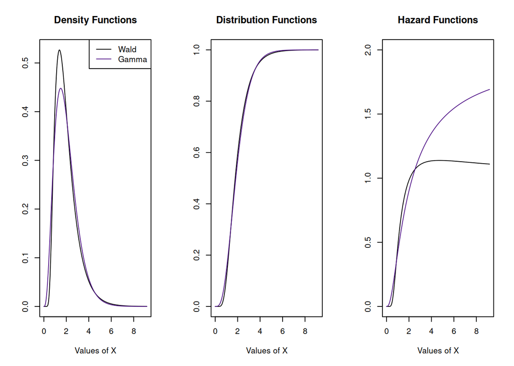

```r
# Define plot points
x <- seq(0,max(X),length=200)

par(mfrow=c(1,3))
plot(x,dwald(x,2,8),type='l',main="Density Functions",xlab="Values of X",
     ylab="")
lines(x,dgamma(x,shape=k,scale=alpha),col="purple4")
legend("topright",c("Wald","Gamma"),lty=1,col=c("black","purple4"))

plot(x,pwald(x,2,8),type='l',main="Distribution Functions",xlab="Values of X",
     ylab="")
lines(x,pgamma(x,shape=k,scale=alpha),col="purple4")

plot(x,dwald(x,2,8)/(1-pwald(x,2,8)),type='l',main="Hazard Functions",ylim=c(0,2),xlab="Values of X",
     ylab="")
lines(x,dgamma(x,shape=k,scale=alpha)/(1-pgamma(x,shape=k,scale=alpha)),col="purple4")
```

The next chunks of code use different estimators for the pdf, cdf, and hazard functions.

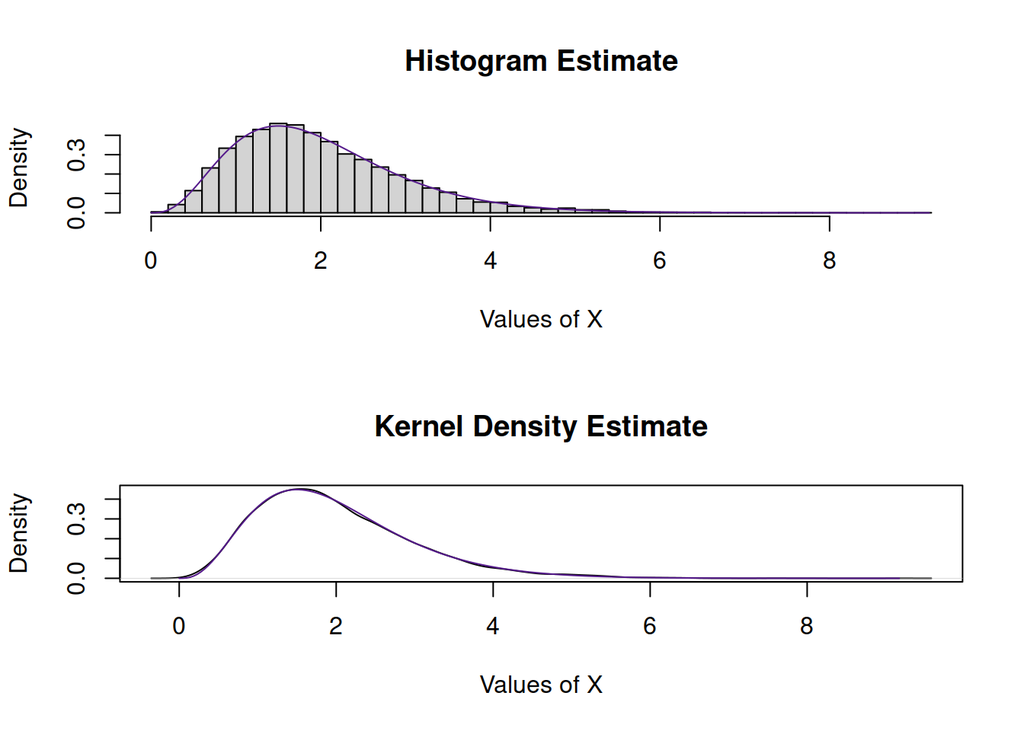

```r
# The simulated data X is of size bignum.  Play with this number.  What happens when it's small vs. big?
# Histogram and kernel estimates of f(x)
par(mfrow=c(2,1))
hist(X,freq=FALSE,breaks=50,main="Histogram Estimate",xlab="Values of X")
lines(x,dgamma(x,shape=k,scale=alpha),col="purple4")

plot(density(X),main="Kernel Density Estimate",xlab="Values of X")
lines(x,dgamma(x,k,scale=alpha),col="purple4")
```

```r
par(mfrow=c(1,1)) # reset to single plots
```

The cdf is easier to estimate. R has an ecdf() function (empirical cumulative distribution function), which computes the *naive* estimator, which is just the cumulative relative frequency.

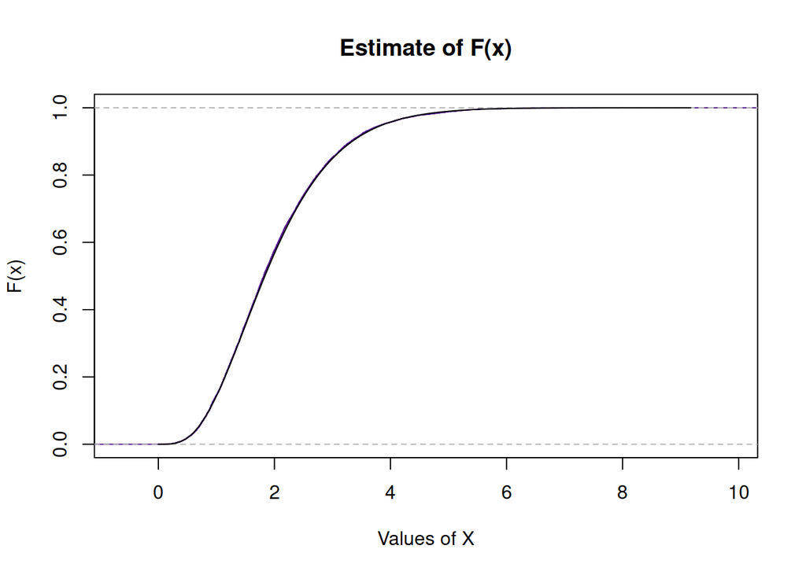

```r
plot(ecdf(X),main="Estimate of F(x)",xlab="Values of X",ylab="F(x)",col="purple4")
lines(x,pgamma(x,k,1/alpha))
```

```r
# Compute the "true" hazard function
true.h <- dgamma(x,shape=k,scale=alpha)/(1-pgamma(x,shape=k,scale=alpha))

# Kernel estimate
# These will be very slow for large values of bignum
kernel.h <- hazard(X)

# Piecewise exponential estimate
pe.h <- pehaz(X)
```

```
##
## max.time= 9.173754
## width= 0.1817428
## nbins= 51
```

I separated out the estimation from the plot procedures because the estimations take some time. Reduce the value of bignum in Probability if you want to speed it up.

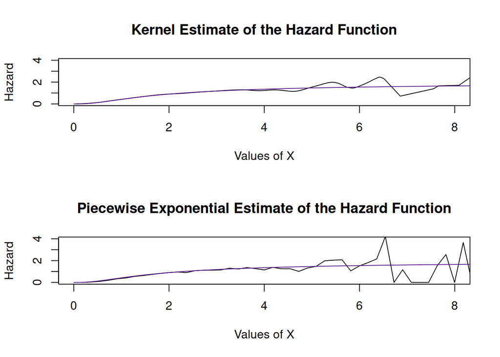

```r
# Create two plots of the two hazard estimates with the "true" gamma hazard
par(mfrow=c(2,1))
plot(kernel.h[,1],kernel.h[,2],xlim=c(0,8),ylim=c(0,4),type='l',
     main="Kernel Estimate of the Hazard Function",
     xlab="Values of X",ylab="Hazard")
lines(x,true.h,col="purple4")
plot(pe.h$Cuts[-1],pe.h$Hazard,xlim=c(0,8),ylim=c(0,4),type='l',
     main="Piecewise Exponential Estimate of the Hazard Function",
     xlab="Values of X",ylab="Hazard")
lines(x,true.h,col="purple4")
```

## Wagenmakers Data

Estimate the pdf, cdf, and hazard functions for a subset of the Wagenmakers dataset.

```r
# Subset the data
Y <- subset(wagenmakers,subject==1 & task == 3 & long==1)

# Compute the estimates
density.y <- density(Y$RT)  # kernel estimate
cdf.y <- ecdf(Y$RT) # naive estimator
hazard.y <- pehaz(Y$RT) # piecewise exponential
```

```
##
## max.time= 1205
## width= 37.65625
## nbins= 32
```

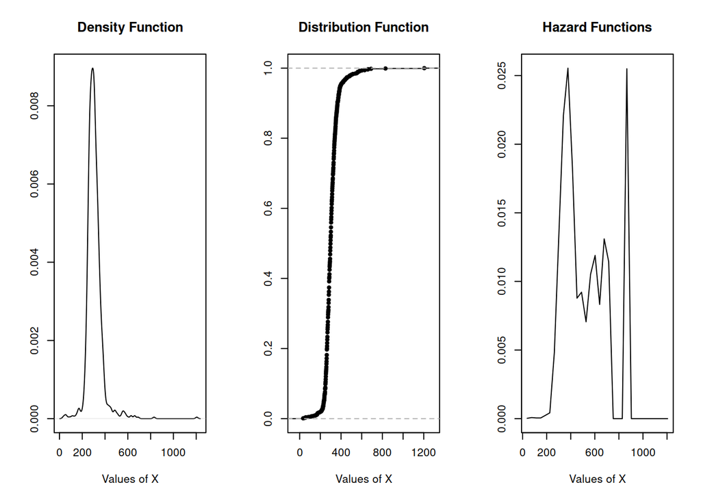

```r
# Plot the estimates
par(mfrow=c(1,3))
plot(density.y,type='l',main="Density Function",xlab="Values of X",
     ylab="")
plot(cdf.y,,main="Distribution Function",xlab="Values of X",
     ylab="")
plot(hazard.y$Cuts[-1],hazard.y$Hazard,type='l',main="Hazard Functions",xlab="Values of X",
     ylab="")
```

## 2. Your turn!

Estimate the pdf, cdf and hazard functions of the data you simulated. Add the “true” function on top of the estimates. Then estimate the pdf, cdf, and hazard functions of your own data.

```r
# Insert your code here
```

# Likelihood

A likelihood function is a way to measure how well a statistical model explains the data we have. For a specified distribution (e.g., the gamma) we compute the joint probability of the data for different values of the distribution parameters. It is important to remember that the likelihood function is conditioned on the data and is a function of the parameter values.

The likelihood $\mathcal{L}$ for a dataset $Y = \{Y_1, \ldots, Y_N\}$ for a model $f_Y(y|\theta)$ is the product of the values of the density function for each of the values of $Y$:
$$\mathcal{L}(\theta|Y) = \prod_{i=1}^N f_Y(Y_i|\theta).$$

Because this product can be difficult to work with we often transform the likelihood to the log likelihood:
$$\ln \mathcal{L}(\theta|Y) = \sum_{i=1}^N \ln f_Y(Y_i|\theta).$$

R makes it easy to compute the log likelihood function by way of the “log=TRUE” option that can be passed to the density function for each quad.

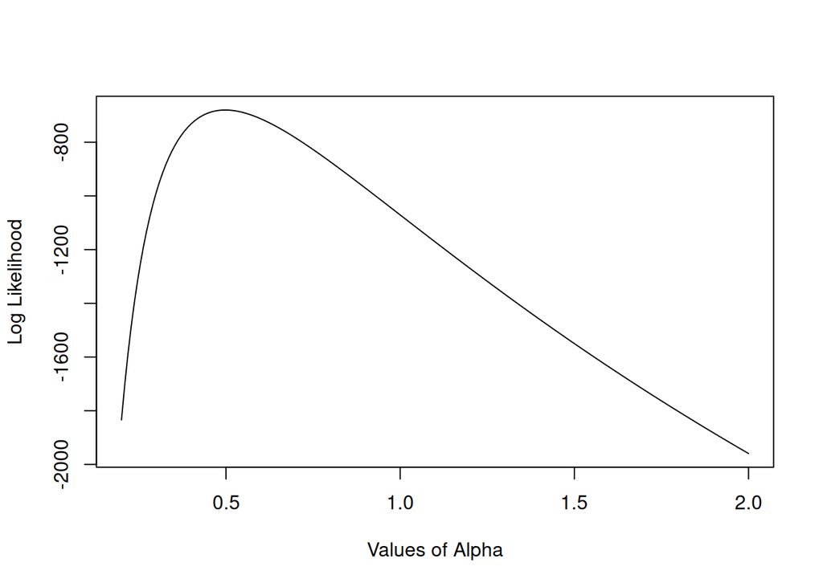

```r
# Compute the likelihood of the simulated data X
log.like <- sum(dgamma(X,shape=k,scale=alpha,log=TRUE))
like <- exp(log.like)

# Plot the likelihood values for different values of alpha
alpha.range <- seq(.2,2,length=200)

log.like <- vector()
for (i in 1:length(alpha.range)) {
  log.like[i] <- sum(dgamma(X[1:500],shape=k,scale=alpha.range[i],log=TRUE))
}
plot(alpha.range,log.like,type='l',xlab="Values of Alpha",ylab="Log Likelihood")
```

# Fitting a Model

A model-fitting exercise is simply the estimation of model parameters given the data observed. There are many ways this can be done.

In the code below we will explore

1. Method of moments
2. Least squares
3. Likelihood maximization
4. Bayesian estimation

## Method of Moments

Perhaps the easiest way to fit a model to data is to use the method of moments.

A distributional moment is a function of the powers of the variable. The $n^{th}$ *raw* moment of a variable $X$ is the expected value (population mean) of the variable $X^n$. The $n^{th}$ *central* moment of a variable is the expected value of $[X - E(X)]^n$. So, the distribution mean $\mu$ is the first raw moment of a distribution and the variance $\sigma^2$ is the second central moment. Skewness $\kappa_3$ is related to the 3rd moment and kurtosis to the 4th.

The mean and variance (and skewness and kurtosis and etc.) of a distribution are a function of that distribution’s parameters. For example, consider the gamma distribution, which has a shape parameter $k$ and a scale parameter $\alpha$. The mean of the distribution is $k \alpha$ and the variance is $k \alpha^2$. So if

$$\begin{eqnarray*}
E(X) & = & k \alpha \text{ and}\\
Var(X) & = & k \alpha^2
\end{eqnarray*}$$

then

$$\begin{eqnarray*}
k & = & E(X)^2/Var(X) \text{ and}\\
\alpha & = & Var(X)/E(X).
\end{eqnarray*}$$

This suggests that good guesses for $k$ and $\alpha$ might be

$$\begin{eqnarray*}
\hat{k} & = & \overline{X}^2/s^2 \text{ and}\\
\hat{\alpha} & = & s^2/\overline{X}.
\end{eqnarray*}$$

Let’s try this for the subset of the Wagenmakers data.

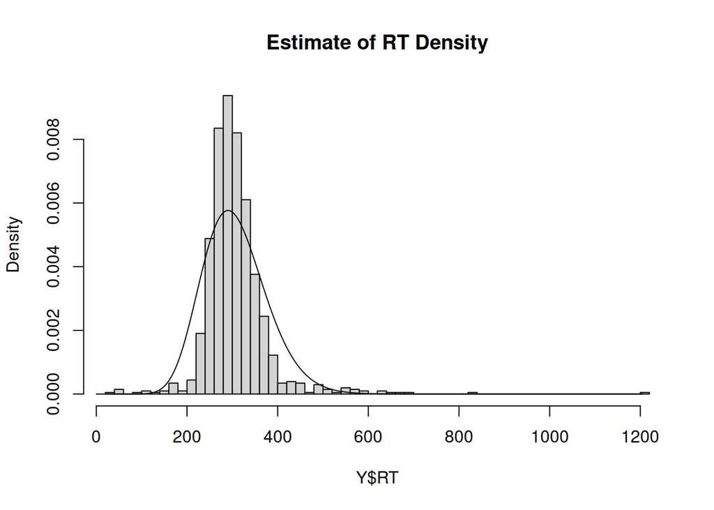

```r
mean.Y <- mean(Y$RT)
var.Y <- var(Y$RT)

k.hat <- mean.Y^2/var.Y
alpha.hat <- var.Y/mean.Y

# Examine the fit
y.values <- seq(0,max(Y$RT),length=400)
hist(Y$RT,freq=FALSE,breaks=50,main="Estimate of RT Density")
lines(y.values,dgamma(y.values,k.hat,scale=alpha.hat))
```

The estimate of k is very large (18.8032314). As the gamma shape parameter grows, the gamma distribution tends to the normal. The reason k.hat is large is because RT distributions have a delay – we don’t start seeing responses until around 200 ms after the stimulus presentation. The fit might be improved by adding a shift, so that $RT = Y + c$, where $Y$ is distributed as a gamma.

The method of moments requires that we add a third moment to estimate $c$. Skewness, the third central moment of the gamma distribution is $\kappa_3 = 2/\sqrt{k}$. This implies that

$$\begin{eqnarray*}
\hat{k} & = & 4/\kappa_3^2, \\
\hat{\alpha} & = & s \kappa_3 / 2 \text{ and} \\
\hat{c} & = & \overline{Y} - s/\kappa_3.
\end{eqnarray*}$$

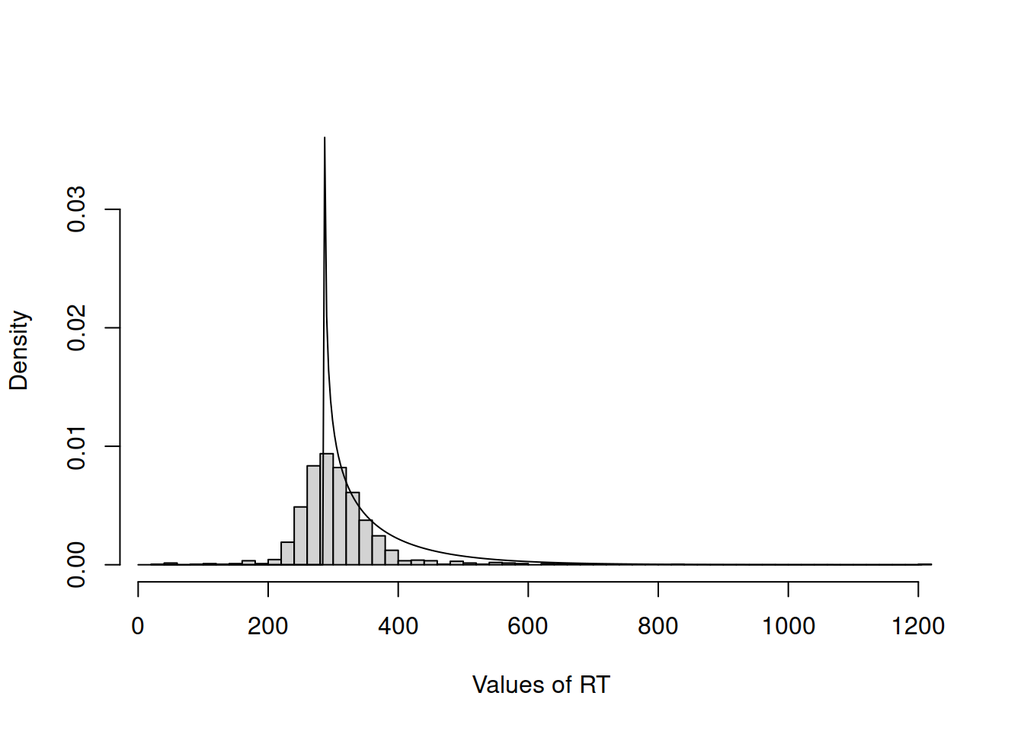

```r
k.hat <- 2/skewness(Y$RT)
alpha.hat <- sd(Y$RT)*skewness(Y$RT)/2
c.hat <- mean(Y$RT) - sd(Y$RT)/skewness(Y$RT)

hist(Y$RT,freq=FALSE,breaks=50,main="",xlab="Values of RT",ylim=c(0,.0361))
lines(y.values,dgamma(y.values-c.hat,k.hat,scale=alpha.hat))
```

As you can see, shifting the distribution and using method of moments didn’t work very well.

### 3. Your turn

Estimate the parameters of your data set using method of moments. Select a model distribution for which the mean, variance, and potentially higher moments are well defined. As I did above, evaluate the fit of your model by plotting the density estimate (histogram or kernel density) against the model density using the estimated parameter values. Then, add a shift parameter $c$ (so $RT = Y + c$), recalculate the method of moments estimators, and again evaluate the fit.

Some things to consider:

1. Do the estimated parameter values make sense?
2. Is the fit (match) acceptable?
3. Are the parameter constraints (e.g., positive, less than one, etc.) guaranteed to be preserved with this method?

```r
# Insert your code here
```

## Nonlinear Least Squares

Fitting a model to data is often cast as an optimization problem, in which the goal is to optimize (maximize reward or minimize penalty) some *objective function* by systematically varying parameter values. For methods of least squares, the objective function is the sum of squared differences between observed and predicted values. In some cases (linear regression) we can solve for the optimal parameter values exactly. In other cases we need to perform a search of the parameter space to try and find those optimal values.

### The optim() function

The optim() function takes as arguments par (a vector of parameter starting values), fn (the objective function), gr (the gradient, which we won’t discuss), method (the search algorithm), lower and upper (the allowable range of the parameters), control (a list of control parameters for the search algorithm), and hessian (a logical variable that indicates whether a Hessian matrix should be returned, another thing we won’t discuss). The function returns, among other things, par (the set of parameters that optimizes the objective function), value (the maximized or minimized value of the objective function), and convergence (a code that indicates whether the search was successful).

The optim function implements a number of different search algorithms. The default search algorithm is the Nelder-Mead (1965) simplex algorithm. A simplex is a geometric object (polytope) with $N+1$ vertices that wiggles around in $N$-dimensional space, where $N$ is the number of parameters you are trying to find. This is a simple and reliable (if slow) algorithm for well-behaved objective functions.

```r
# Define an objective function
ss <- function(c,x) sum((x-c)^2)

# Generate some data
fake.data <- rnorm(100,100,15)

# What value of central tendency minimizes the variance?
mu.hat <- 10 # Initial guess for c

fit <- optim(par=mu.hat,ss,x=fake.data)
```

The least-squares estimate of $c$ is 101.75, which is close to the value $c=100$ that generated the data. The minimized value of the ss function is 2.706672^{4}. The convergence code is 0, indicating that the search algorithm successfully found a minimum (0) or failed to converge (1).

You may remember that the sample mean $\overline{X}$ is the measure of central tendency $C$ that minimizes the sum of squared deviations $\sum_{i=1}^N (X_i - C)^2$. It might be interesting to you to compare the optimized value of ss() to the numerator of the sample variance $s^2$, and to compare the least-squares estimate of $c$ to the sample mean $\overline{X}$.

```r
cat("The sample mean is ",mean(fake.data),"and the estimated mean is ",fit$par,".\n")
```

```
## The sample mean is  101.7454 and the estimated mean is  101.75 .
```

```r
cat("The sample sum of squares is ",(length(fake.data)-1)*var(fake.data),"and the optimized ss is ",fit$value,".")
```

```
## The sample sum of squares is  27066.72 and the optimized ss is  27066.72 .
```

One thing to note is that optim() minimizes functions by default (but this can be changed with the control argument). If your optimization requires maximization instead (such as maximum likelihood, see below), then make sure you define your objective function such that minimizing it actually maximizes what you want. That is, multiply your objective function by -1.

### The objective function

For nonlinear least squares we need to figure out what aspect of the RT distribution should enter into the objective function. A reasonable choice is to try to match the empirical cdf to the theoretical cdf. Here is a function that computes the sum of squared deviations between an empirical cdf and the gamma cdf. A non-decisional (shift) term is included.

```r
# The array est.cdf contains the RT values in the 1st column and the cdf in the 2nd column.
# The pars vector contains the starting values for the gamma distribution on an infinite scale.
ss.gamma <- function(pars,est.cdf) {
   # Note reparameterization!  Exponentiating the parameter values insures that they are all positive.
   k <- exp(pars[1])
   alpha <- exp(pars[2])
   c <- exp(pars[3])

   F.hat <- est.cdf[,2]
   points <- est.cdf[,1]

   # If you modify this function to fit a different distribution make sure you also change the parameters in
   # all necessary ways.
   ss <- sum((F.hat - pgamma(points-c,k,scale=alpha))^2)
   return(ss)
   }
```

In the following chunk of code, we will fit a gamma distribution to the subsetted Wagenmakers data using least squares. We will first compute the empirical cdf with the quantile() function.

```r
p <- seq(.01,.99,by=.01)
times <- quantile(Y$RT,p)
est.cdf <- cbind(times,p)
```

Now we will pass the estimated cdf to the ss.gamma() function through the optimization function optim(). We’ll use the method of moments estimates of the gamma parameters as a starting point. Because the ss.gamma() function exponentiates the parameter values we will need to start with the logged method of moments estimates.

```r
# Use the method of moment estimates as starting values
start.pars <- log(c(k.hat,alpha.hat,c.hat)) # We'll exponentiate these inside ss.gamma
fit.gamma <- optim(start.pars,ss.gamma,est.cdf=est.cdf)
```

The next step is an initial evaluation of the fit of the model by plotting the observed distribution against the best-fitting gamma distribution. We can look at both the density and the cdf.

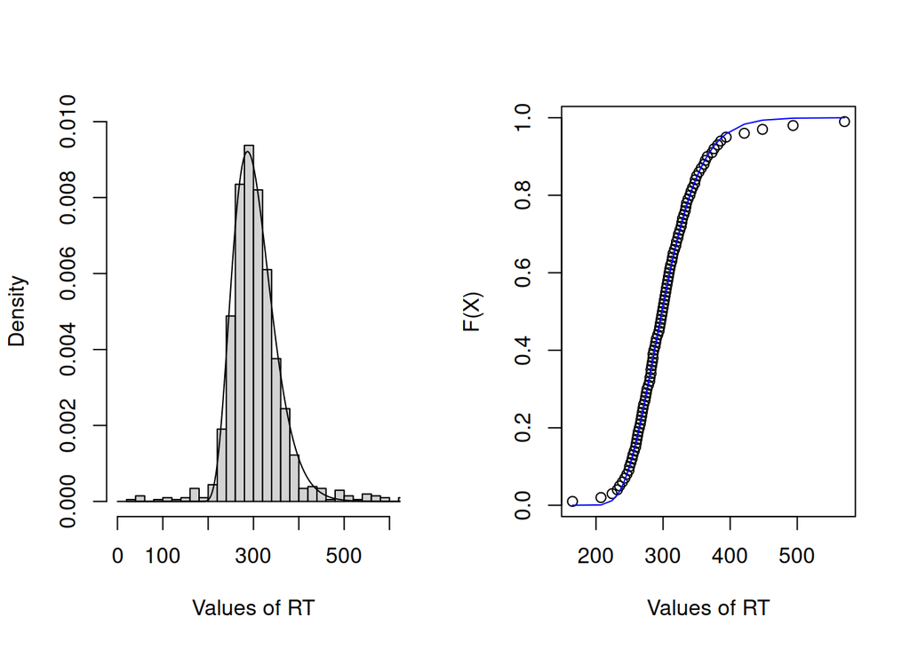

```r
# Exponentiate the recovered parameters and assign them to k, alpha, and c
ss.pars <- exp(fit.gamma$par)
k.hat <- ss.pars[1]
alpha.hat <- ss.pars[2]
c.hat <- ss.pars[3]

# Plot the observed and theoretical density and distribution functions
par(mfrow=c(1,2))
hist(Y$RT,freq=FALSE,breaks=50,main="",xlab="Values of RT",
     xlim=c(0,600),ylim=c(0,.01))
lines(y.values,dgamma(y.values-c.hat,k.hat,scale=alpha.hat))

plot(times,p,xlab="Values of RT",ylab="F(X)",type='p')
lines(times,pgamma(times-c.hat,k.hat,scale=alpha.hat),col="blue")
```

Another way to evaluate the goodness of fit visually is the QQ plot, which simply plots the observed quantiles as a function of the theoretical quantiles. A good fit is exhibited by all the points lying on the identity line $y=x$.

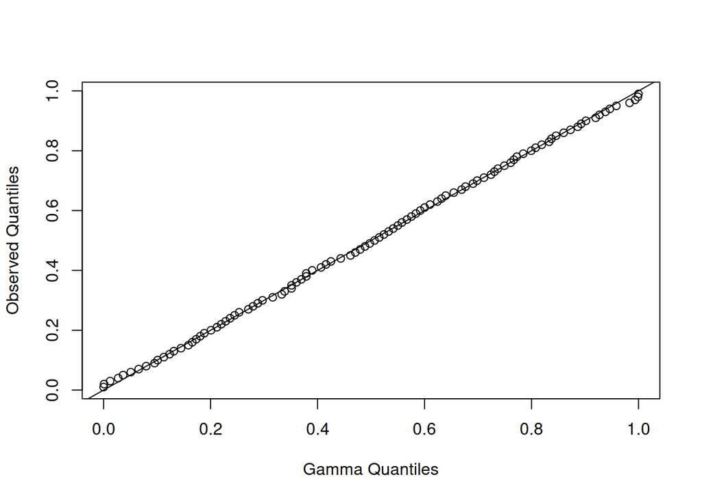

```r
plot(pgamma(times-c.hat,k.hat,scale=alpha.hat),p,type='p',
     xlab="Gamma Quantiles",ylab="Observed Quantiles")
abline(0,1)
```

This a a remarkably good fit.

### 4. Your turn!

Fit a gamma or other model to your own data using least squares. If you are using the Wagenmakers dataset try to fit a Wald (pwald, for the cdf) or ex-Gaussian model.

## Maximum Likelihood

The difference between least squares minimization and likelihood maximization is in the objective function to be used. You computed a likelihood earlier, and recall that the likelihood is based on the joint probability of the data (as given by a model), but is a function of the parameter values and not the data.

Let’s first define an appropriate likelihood function for the gamma model we’ve been using, and then pass it through R’s optim() function. Before we do this, note two things.

1. The log of a variable is a monotonic function of that variable. That is, if the variable increases the log of it also increases. Similarly, if the variable decreases the log of it also decreases. This means that the parameters that maximize the likelihood function will also maximize the log likelihood. Because it is much easier and avoids numerical under- and overflows, we will work with the log likelihood function.
2. Because we want to maximize the log likelihood function and optim()’s default is to minimize, we are going to define the *negative* log likelihood. Minimizing the negative log likelihood maximizes the positive log likelihood.

```r
# Define the negative log likelihood function for the gamma model
ll.gamma <- function(pars,X) {
  # Reparameterize so that the model parameters are appropriately positive
  k <- exp(pars[1])
  alpha <- exp(pars[2])
  c <- exp(pars[3])

  ll <- -sum(dgamma(X-c,k,scale=alpha,log=TRUE))

  # Uncomment these lines (see below) to eliminate the error and rerun this code chunk
  #  lls <- dgamma(X-c,k,scale=alpha,log=TRUE)
  #  lls[abs(lls)==Inf] <- -500
  #  ll <- -sum(lls)
  return(ll)
}
```

Now as for the least squares estimation, pass the ll.gamma function through the optim() function.

```r
# Select starting values
# start.pars <- log(c(k.hat,alpha.hat,c.hat)) # Method of moments estimates
start.pars <-  fit.gamma$par # Least squares estimates
fit.gamma.ll <- optim(start.pars,ll.gamma,X=Y$RT)
```

When you run this code chunk you might get an error like this:

> Error in optim(start.pars, ll.gamma, X = Y$RT) : function cannot be evaluated at initial parameters

Usually this means that the objective function is returning values like NaN (not a number) or Inf (infinity, positive or negative) for one, some, or most of the values in the dataset. You need to either try a different set of starting values or (and) “nudge” the algorithm in the right direction.

If the log likelihood of a datapoint is negative infinity, the likelihood is zero. To avoid infinities, choose instead some very “big” negative number that, when exponentiated, would be pretty close to 0. Substitute this value into the likelihood computation directly. If you get this error, go back to the negative log likelihood function and uncomment the indicated lines of code.

When you have eliminated the error, come back to this point and evaluate the fit.

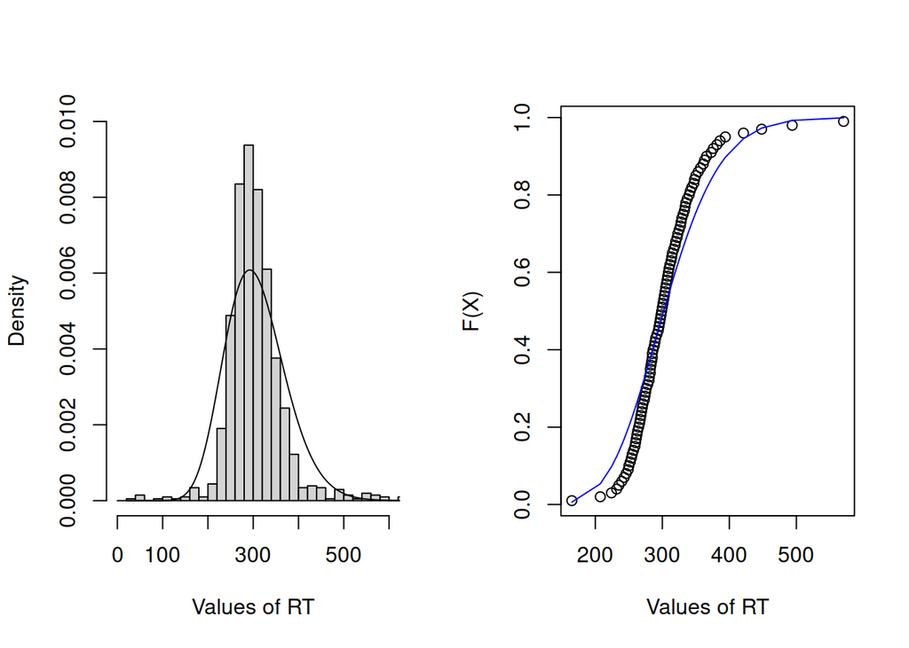

```r
# Exponentiate the recovered parameters and assign them to k, alpha, and c
ss.pars <- exp(fit.gamma.ll$par)
k.hat <- ss.pars[1]
alpha.hat <- ss.pars[2]
c.hat <- ss.pars[3]

# Plot the observed and theoretical density and distribution functions
par(mfrow=c(1,2))
hist(Y$RT,freq=FALSE,breaks=50,main="",xlab="Values of RT",
     xlim=c(0,600),ylim=c(0,.01))
lines(y.values,dgamma(y.values-c.hat,k.hat,scale=alpha.hat))

plot(times,p,xlab="Values of RT",ylab="F(X)",type='p')
lines(times,pgamma(times-c.hat,k.hat,scale=alpha.hat),col="blue")
```

You can see that the least squares method resulted in a much better fit than the likelihood maximization method. Likelihood maximization doesn’t usually fail in this way.

### 5. Your turn!

Why do you think the likelihood maximization resulted in poorer fits than the least squares minimization? (Hint: Go back to those data points that gave -Inf for the log likelihood. What is it about those points that made this happen? How was this prevented in the least squares procedure?)

How might you modify the model given your understanding of what is happening?

### 6. Your turn!

Fit the Wald (dwald(X,mu,lambda)) or exGaussian (dexGAUS(X,mu,sigma,tau)) model to your own data. Change the model in the objective function(s) appropriately, and don’t forget to adjust the parameter values appropriately.

```r
# Insert your code here
```

## 7. Your turn!

We only fit a single condition from a single participant from the Wagenmakers dataset. Now consider fitting two conditions. You will probably want to use two sets of parameter values, or some parameters will vary with condition while others will remain constant.

Here is where your psychological interpretation of the parameters is going to be important. For example, if we model RTs with a gamma distribution, because of the link between the gamma distribution and Poisson information accumulator models, the shape parameter represents an information threshold and the inverse of the scale parameter is the rate at which information comes into the system.

For the Wagenmakers data, consider the simple response task (Task 1). There are some theories (e.g., Laming, 1966) suggesting that information accumulation occurs even in the absence of a stimulus. The longer the RSI, the more random noise might be accumulated, resulting in an increase in the amount of information in the system at the time of stimulus presentation. So, you might guess that the RSI manipulation would influence the threshold (k) or the shift (c).

```r
# Compute the condition means and display those for Task 1
w.means<-aggregate(wagenmakers$RT,by=list(wagenmakers$subject,wagenmakers$task,wagenmakers$long),mean)
w.means[w.means$Group.2==1,]
```

|  | Group.1 | Group.2 | Group.3 | x |
| --- | --- | --- | --- | --- |
| 1 | 1 | 1 | 1 | 496.3529 |
| 2 | 2 | 1 | 1 | 582.3027 |
| 3 | 3 | 1 | 1 | 538.0713 |
| 4 | 4 | 1 | 1 | 504.0820 |
| 5 | 5 | 1 | 1 | 441.7627 |
| 6 | 6 | 1 | 1 | 461.3555 |
| 19 | 1 | 1 | 2 | 543.7500 |
| 20 | 2 | 1 | 2 | 523.8018 |
| 21 | 3 | 1 | 2 | 630.7100 |
| 22 | 4 | 1 | 2 | 485.2021 |

[output cut: 2 more lines]

How might you parameterize the gamma model so that you can fit two conditions at the same time? Here is one suggestion: the long variable takes values 1 (for short) and 2 (for long). You could write the parameter $k$ as
$$k= k_0 + (long-1)*dk$$
for two parameters $k_0$ and $dk$, where $dk$ is the “effect” of increasing the RSI.

Modify the least-squares or likelihood objective function to fit the two RSI conditions at the same time for a single participant in a single task. Fit the new model and evaluate the fit to the data using visualizations of the density or cdf.

```r
# Insert your code here
```

# Model Comparison

The gamma model with a shift has three parameters. The diffusion model has as many as 9. We might expect, therefore, that the diffusion model fits better than the gamma model purely on the basis of its larger number of parameters. How do we determine if the added parameters are necessary?

We’re going to use the mystery dataset for this part.

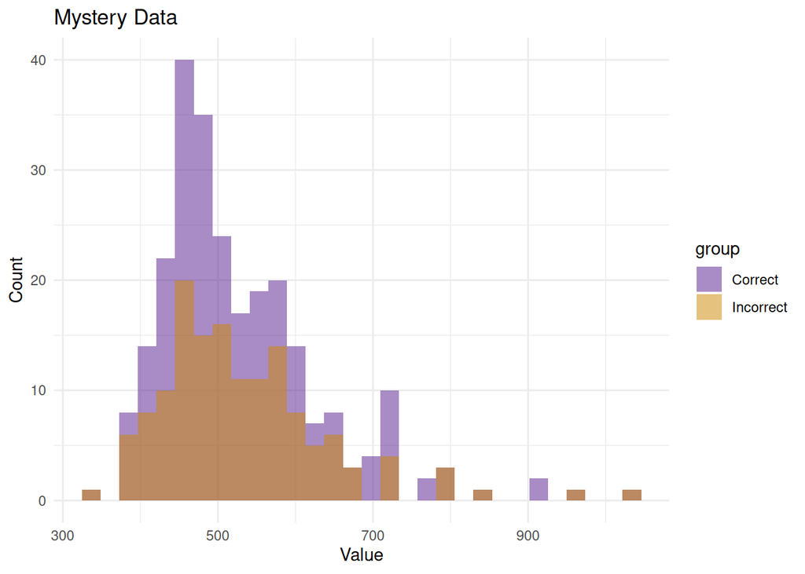

```r
load("mystery.Rdata")

library(ggplot2)

# Mystery data has two stimulus conditions.  For now, just look at one of them
# (stim = 0).
# Combine the correct and incorrect RTs into a data frame, with an additional group identifier
data <- data.frame(
  value = c(rt[re==0 & stim==0], rt[re==1 & stim==0]),
  group = factor(c(rep("Incorrect", length(rt[re==0])), rep("Correct", length(rt[re==1]))))
)

# Plot the histograms
ggplot(data, aes(x = value, fill = group)) +
  geom_histogram(alpha = 0.5, position = "identity", bins = 30) +  # Use 'position = identity' to overlay
  scale_fill_manual(values = c("purple4", "orange3")) +                   # Custom colors for distinction
  labs(title = "Mystery Data", x = "Value", y = "Count") +
  theme_minimal()
```

## Likelihood Ratio Test

The likelihood ratio test is used for nested models. It is a way to determine if added parameters are necessary to improve model fit.

Let $\Theta$ be the parameter space of the full model and $\Theta_0$ the parameter space of the nested model with fewer parameters. Also let $\sup_{\theta}\mathcal{L}(\theta|X)$ be the value of the maximized likelihood function (so $\theta$ are the maximum likelihood estimates).

The hypotheses we will test are
$$\begin{eqnarray*}
H_0: && \theta \in \Theta_0 \\
H_1: && \theta \in \Theta,
\end{eqnarray*}$$
where $\Theta_0$ is the set of allowable parameter values for the reduced model that is nested within $\Theta$, the set of allowable parameter values for the full model.

The log likelihod ratio test statistic is
$$\lambda = -2 [\sup_{\theta \in \Theta_0} \ln \mathcal{L}(\theta ~|~ X)
- \sup_{\theta \in \Theta} \ln \mathcal{L}(\theta|X)],$$

which follows a $\chi^2$ distribution with $k$ degrees of freedom, where $k$ is the number of parameters by which $\Theta_0$ is reduced.

Consider the gamma model with and without a shift. Let’s modify the likelihood function to permit us to indicate that we might not want a shift parameter.

```r
ll.gamma.new <- function(pars,X,shift=0) {
  # If shift=0 then the parameter c=0
  # Reparameterize so that the model parameters are appropriately positive
  k <- exp(pars[1])
  alpha <- exp(pars[2])
  c <- shift*exp(pars[3]) # Zero out c if shift=0

  ll <- -sum(dgamma(X-c,k,scale=alpha,log=TRUE))

   lls <- dgamma(X-c,k,scale=alpha,log=TRUE)
   lls[abs(lls)==Inf] <- -500
   ll <- -sum(lls)
  return(ll)
}
```

Now fit the gamma model to the correct RTs in the mystery data with and without the shift parameter.

```r
X <- rt[re==1 & stim==0]

# Select starting values and fit the two models
start.pars <- log(c(4,125,100)) # arbitrary
fit.full.gamma <- optim(start.pars,ll.gamma.new,X=X,shift=1)
fit.reduced.gamma <- optim(start.pars,ll.gamma.new,X=X,shift=0)
```

Note that the reduced model has a nonzero value for the shift. This doesn’t matter; the algorithm tried different values for $c$ but none of those values changed anything because the likelihood function always zeroed them out. This is not the most efficient way to restrict a parameter but it is the easiest.

Let’s take a quick peek at these two fits by plotting the predicted densities over the RT histogram.

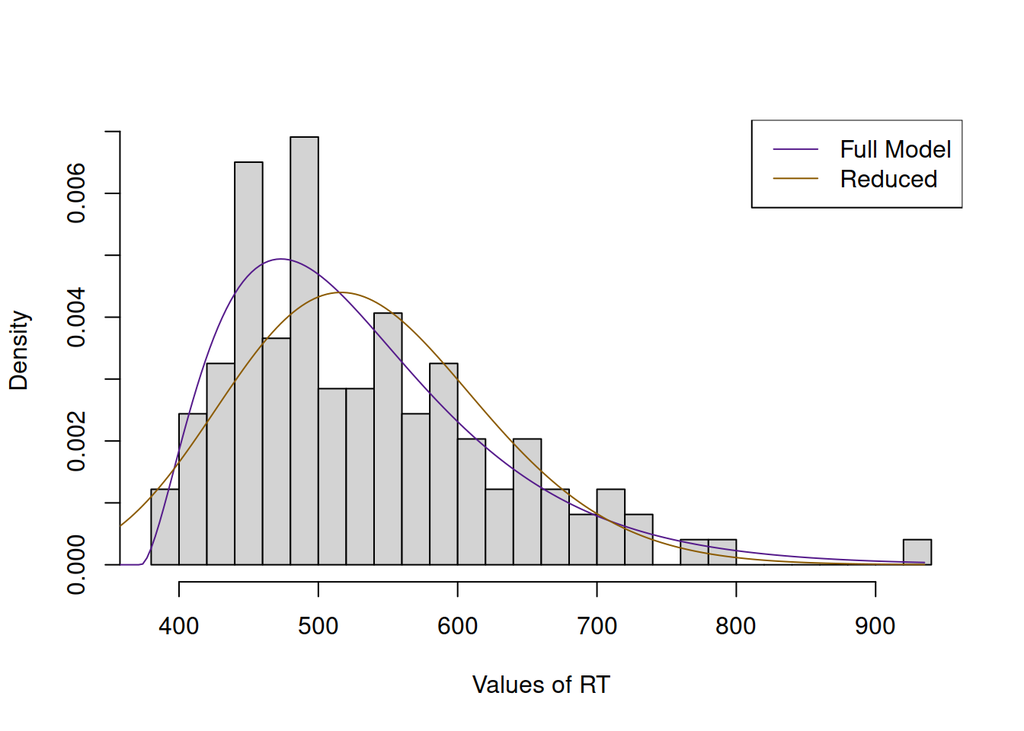

```r
x <- seq(min(X)-50,max(X)+10,length=200) # for plotting

# Convert the log parameter values
full.pars <- exp(fit.full.gamma$par)
reduced.pars <- c(exp(fit.reduced.gamma$par),0)

hist(X,breaks=30,freq=FALSE,xlab="Values of RT",main="")
lines(x,dgamma(x-full.pars[3],full.pars[1],scale=full.pars[2]),
      col="purple4")
lines(x,dgamma(x,reduced.pars[1],scale=reduced.pars[2]),
      col="orange4")
legend("topright",c("Full Model",
                    "Reduced"),lty=1,col=c("purple4","orange4"))
```

Compute $\lambda$ from the values of the maximized likelihoods. Remember that we multiplied the likelihood function by -1 so that optim() could use its default minimization, so multiply those values by -1 to flip it back. (Both likelihoods are negative so this will not matter but I like to be precise.)

```r
lambda <- -2*(-fit.reduced.gamma$value-(-fit.full.gamma$value))
```

There is one less parameter in the reduced model, so the $\lambda$ statistic is distributed as a $\chi^2$ with 1 degree of freedom. The $p$-value of $\lambda$ is 2.7790899^{-5}. This value is less than any reasonable $\alpha$ level so we reject the null hypothesis in favor of the full model.

## Root Mean Squared Error of Prediction, $R^2$ and $\chi^2$ Goodness of Fit

Models make predictions. With distributional analyses it is less clear what the prediction is. Is it the height of the density function vs. the histogram? Is it the quantiles of the distribution? Or is it something else?

We often choose a “prediction” in the distributional context to be something related to how we fit the model. So, for example, we minimized the sum of squared errors between the observed and predicted quantiles to fit the gamma model. The predictions might then be the distribution quantiles. We might then, using the observed and predicted quantiles, compute the root mean squared error of prediction, $R^2$ or $\chi^2$ to evaluate how well the model fit.

This is a way of “double dipping,” using the data in two different ways for two purposes. One way is the minimization for the parameter estimation, and the other way is to quantify the goodness of fit using the same function that we used to estimate the parameters. This is not good statistical practice. It results in an overestimate of the goodness of fit of the model. The model may be overfit, so that the model accounts for random error, and will fail to generalize to new data.

A way around this is to divide the data into a training set, to which the model is fit, and a test set, for which the goodness of fit is evaluated. This is called cross-validation, and is the best way to quantify the fit of a model without double dipping.

```r
# Do an 80% split of the data
# Which RTs will be in the training set?
indices <- sample(length(X),round(.8*length(X)),replace=FALSE)
train <- X[indices]
test <- X[-indices] # the rest will be the test set
```

The root mean squared error of prediction (RMSE) is the square root of the mean squared errors between observed values $Y$ and predicted values $\hat{Y}$. This makes sense in a regression context where $\hat{Y}$ is a function of a set of predictor variables $\{X\}$. Similarly, the squared correlation coefficient $R^2$ quantifies the extent to which a linear relationship describes the relationship between the prediction and the observations. The $\chi^2$ goodness of fit test examines how well the model distribution predicts the frequency distribution of the data.

First fit the gamma model to the training RT data using least squares.

```r
# Construct the empirical cdf for the training data
p <- seq(.01,.99,by=.01)
times <- quantile(train,p)
est.cdf <- cbind(times,p)

# Choose starting values
start.pars <- fit.full.gamma$par

# Estimate the gamma parameters using least squares
fit.train <- optim(start.pars,ss.gamma,est.cdf=est.cdf)
gamma.pars <- exp(fit.train$par)
```

Use the test set to evaluate the fit. Start by computing the RMSE and $R^2$.

```r
# Compute the RMSE and R^2 based on the quantiles
pred.quantiles <- qgamma(p,gamma.pars[1],scale=gamma.pars[2])+gamma.pars[3]
obs.quantiles <- quantile(test,p)
rmse <- sqrt(mean((pred.quantiles-obs.quantiles)^2))
r2 <- cor(pred.quantiles,obs.quantiles)^2
```

The RMSE is 20.9974743, and $R^2$ is 0.9696435.

Finally do a $\chi^2$ goodness of fit test.

```r
# Compute the chi^2 GOF statistic based on the deciles.  There should be
# 10% of the observations between each decile
pred.deciles <- qgamma(seq(.1,.9,by=.1),gamma.pars[1],
                       scale=gamma.pars[2])+gamma.pars[3]
E <- length(test)*.1 # expected frequency

# Compute the observed frequencies using hist
O <- hist(test,breaks=c(min(test),pred.deciles,max(test)),plot=FALSE)$counts

# Compute chi^2
chi2 <- sum((E-O)^2/E)

# Compute the p-value.  Note that the degrees of freedom is the number of
# cells minus 1
1-pchisq(chi2,10-1)
```

```
## [1] 0.1296196
```

### 8. Your turn

The RMSE and $R^2$ statistics for a single model fit don’t say much. We use them comparatively: fit two different models and use RMSE and $R^2$ to determine which model is better.

Fit two different models to the mystery data (stim=0) or to your own data using either least squares or MLE. Compute the RMSE and $R^2$ and determine which model fits better.

## Kolmogorov-Smirnov Test

Another way to evaluate goodness of fit is the Kolmogorov-Smirnov test. This test evaluates the null hypothesis $H_0: X \sim F(x)$ for some theoretical distribution $F(x)$. The test statistic is the maximum difference between the empirical distribution function and the theoretical (model) distribution function:
$$D = \sup_x \left| \hat{F}(x) - F(x~|~\hat{\theta}) \right|,$$
where $\hat{\theta}$ are the parameter values estimated from the training set and $\hat{F}(x)$ is the empirical estimate for the *test* data. It is important to separate the estimation of the parameters from the test, because if the same data are used to estimate both $\theta$ and $\hat{F}(x)$ then the test is invalid.

```r
# Use the test data to evaluate the null hypothesis given the best-fitting
# gamma parameters estimated from the training data.
ks.test(test-gamma.pars[3],y="pgamma",shape=gamma.pars[1],scale=gamma.pars[2])
```

```
##
##  Exact one-sample Kolmogorov-Smirnov test
##
## data:  test - gamma.pars[3]
## D = 0.12956, p-value = 0.748
## alternative hypothesis: two-sided
```

We *fail to reject* the null hypothesis that the test data were sampled from a gamma distribution with parameters estimated from the training data, and might conclude that the gamma model fits the data well.

# 9. Your turn: Real models

What we’ve done so far is not very realistic. The gamma distribution is not very good for RT data (although it’s flexible), and we’ve only looked at one condition (only one stimulus, only correct responses, etc.).

So let’s fit the ubiquitous drift diffusion model to some data. The drift diffusion model has at least 5 parameters:
$$\begin{eqnarray*}
a: && \text{Response threshold for response } A \\
z: && \text{Starting point, often } a/2 \\
\nu_A: && \text{drift rate for responses to stimulus} A \\
\nu_B: && \text{drift rate for responses to stimulus} B \\
t_0:
&& \text{nondecision time (shift)}
\end{eqnarray*}$$

Here are two websites that will be useful:

1. (https://www.ejwagenmakers.com/EZ.html) gives a web interface for estimating diffusion model parameters for the single condition, two responses situation. This is a great way to generate good starting values for a least squares or MLE of the drift diffusion model.
2. A vignette that uses the rtdists package for two stimuli by two responses is [here](https://cran.r-project.org/web/packages/rtdists/vignettes/reanalysis_rr98.html).

Following the vignette, fit the drift diffusion model to the mystery (or your own) data. Here’s what you’ll need to do:

1. Generate starting values.
2. Format the data appropriately so it can be passed to the objective function.
3. Code up an objective function, inside of which you need to:
   1. Reparameterize to ensure the parameters behave, and
   2. Catch any likelihood values equal to 0 (if you decide to use MLE).
4. Pass the data and the model through the optim() function.
5. Transform the parameters back to meaningful values.
6. Evaluate the model fit with function comparisons, QQ plots, or one of the other methods presented above.
7. Interpret the parameters.

*Note: Sometimes it is important to *iterate* the optimization routine because poor starting values may lead to poor estimated values. But those poor estimated values can be used as new starting values!*

```r
# Insert your code here
```